# Dhx9 RNAseq : Differential expression

@vivekbhr

Wed Jul 20 12:10:34 2016

### Gene counts

For description of gene counts, see 01_diffExpression_samplewise

## edgeR on poly-A transcripts

Results and plots saved under folder edgeR_results. I have used DDR20 to denote siRNA 4020, and DDR19 to denote siRNA 4019.

### DE results: concordance between samples

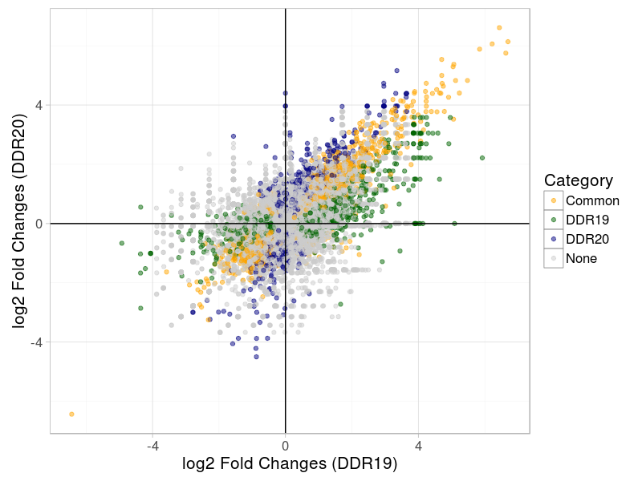

### DE results : selecting DE genes

All the genes which are called differentially expressed in both the KDs, and show concordance between samples (logFC in same direction), are called differentially expressed.

### Numbers

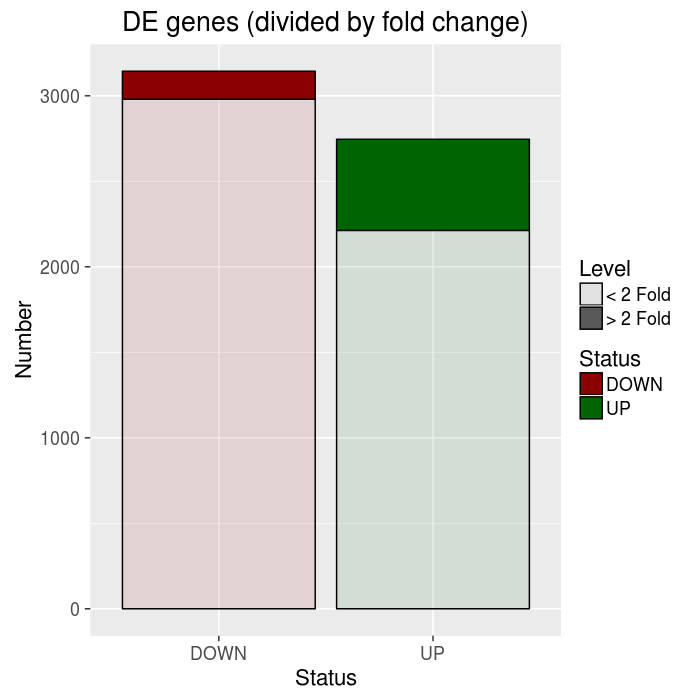

### Visualize the outputs

You can zoom in and out of these plots and search any genes to get the counts.

In this output genes which are upregulated are in Red, while genes which are downregulated are in Blue..

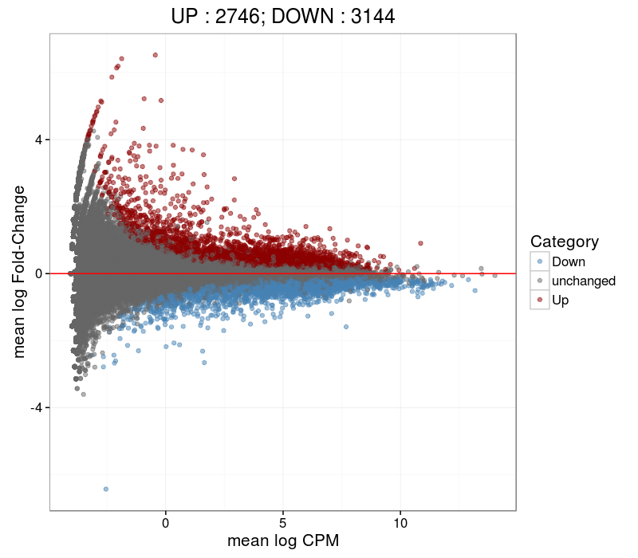

### Plotting individual pathways

I plotted some top pathways enriched by the SPIA analysis on a KEGG map. Below, downregulated pathways are colored in RED, upregulated in dark GREEN, and unchanged in GREY.

Most pathway changes are consistant with the previous KD result, except for HTLV-1 infection, which is now going down, instead of UP in the previous result.

I am plotting previous and new pathways together to visualize the difference.

Noticable difference is that some important genes completely flipped their expression: FZD10, MYC, CDKN2b, while many new genes now show expression in new samples (stronger effect overall).

Cell cycle and cancer have similar effect but the overall direction is not flipped bw old and new.

The reason for the flip is that most DF genes have low fold changes, in both old and new dataset

#### New HTLV pathway

colorScale

[figure not shown]

#### Old HTLV pathway

colorScale

[figure not shown]

### Conclusions

- Around 2.7K genes go Up and 3.1K genes go DOWN. Most are low fold changes.
- All major perturbed pathways are Inhibited, including Cancer and HTLV. They all show downregulation of most genes.